# RStan Workflows

Blake Shurtz

```r
rstan_options(auto_write = TRUE)
options(mc.cores = parallel::detectCores())
```

# 1 Maximim Likelihood Estimation

## 1.1 Import Data

```r
setwd("./1. MLE")
data(Howell1); d <- Howell1; d <- d[ d$age >= 18 , ]
height <- as.numeric(d$height) #create vector using variable names matching stan code
N <- length(d$height)
stan_rdump(c("height", "N"), file="example.data.R")
data <- read_rdump("example.data.R")
```

## 1.2 Prior predictive simulation

for the full model of heights (ie. the model block in stan)

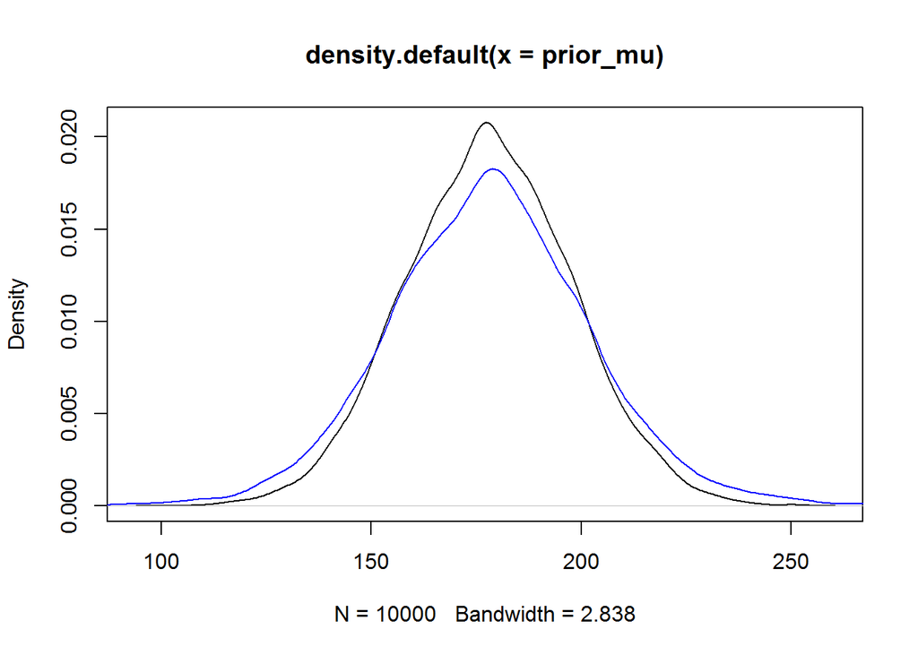

```r
prior_mu <- rnorm( 1e4 , 178 , 20 )
prior_sigma <- rexp( 1e4 , 1/10)
prior_indv <- rnorm( 1e4 , prior_mu , prior_sigma ) #sampling from vectors of mu and sigma, 1 sample from each element?
plot(density(prior_mu))
lines(density( prior_indv), col = 'blue') #wider curve for individual obserations
```

## 1.3 fit it

```r
setwd("./1. MLE")
writeLines(readLines("04_height.stan"))
```

```
## data{
##     int<lower=1> N;
##     real height[N];
## }
## parameters{
##     real mu;
##     real<lower=0> sigma;
## }
## model{
##     sigma ~ exponential( 0.1 );
##     mu ~ normal( 178 , 20 );
##     height ~ normal( mu , sigma );
## }
##
## generated quantities{
##   real y_pred;
##   y_pred = normal_rng(mu, sigma);
## }
```

```r
setwd("./1. MLE")
fit <- stan(file='04_height.stan', data=data, seed=194838, chains = 1, warmup=1000, iter=11000)
#control=list(max_treedepth=15, adapt_delta=0.90), #option for treedepth, divergences
```

## 1.4 overview

```r
print(fit)
```

```
## Inference for Stan model: 04_height.
## 1 chains, each with iter=11000; warmup=1000; thin=1;
## post-warmup draws per chain=10000, total post-warmup draws=10000.
##
##           mean se_mean   sd    2.5%     25%     50%     75%   97.5% n_eff
## mu      154.62    0.01 0.41  153.79  154.35  154.62  154.89  155.42  6543
## sigma     7.76    0.00 0.30    7.21    7.56    7.75    7.96    8.37  8765
## y_pred  154.56    0.08 7.82  139.28  149.34  154.53  159.86  169.90  9968
## lp__   -896.36    0.02 1.02 -899.13 -896.76 -896.05 -895.63 -895.37  4181
##        Rhat
## mu        1
## sigma     1
## y_pred    1
## lp__      1
##
## Samples were drawn using NUTS(diag_e) at Thu Oct 31 14:04:22 2019.
## For each parameter, n_eff is a crude measure of effective sample size,
## and Rhat is the potential scale reduction factor on split chains (at
## convergence, Rhat=1).
```

## 1.5 compare prior and posterior for mu

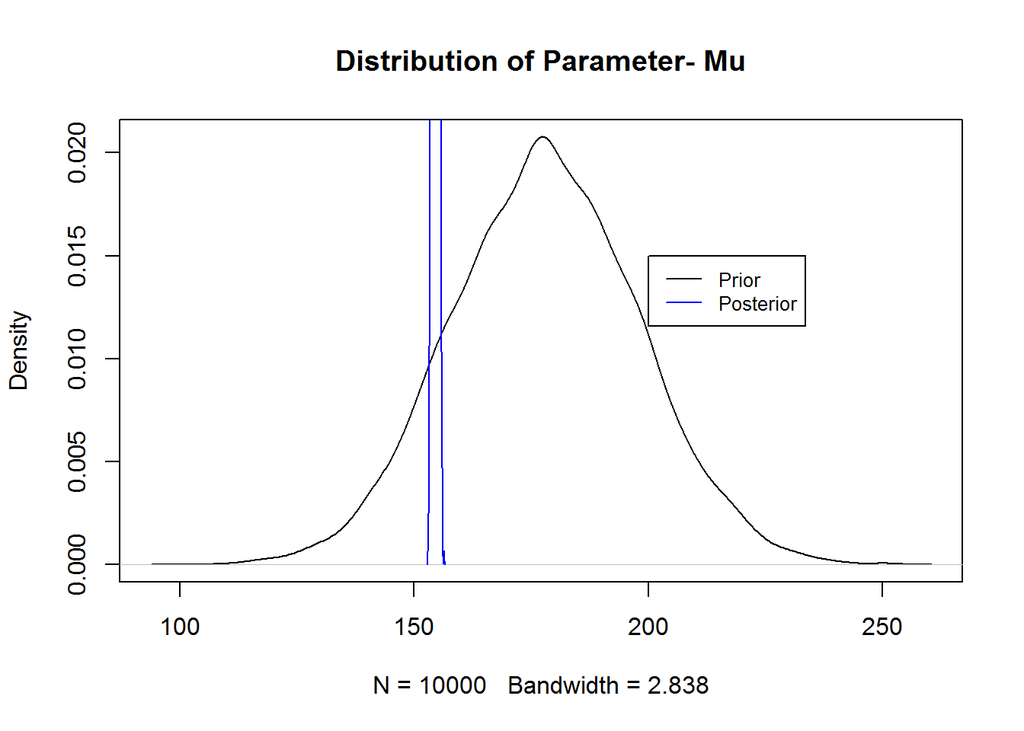

```r
posterior <- as.data.frame(fit)
plot(density(prior_mu), main = 'Distribution of Parameter- Mu') #prior for mu
lines(density(posterior$mu), col = 'blue') #posterior- contracts
legend(200, .015, legend=c("Prior", "Posterior"), col=c("black", "blue"), lty=1:1, cex=0.8)
```

## 1.6 compare prior and posterior for individuals

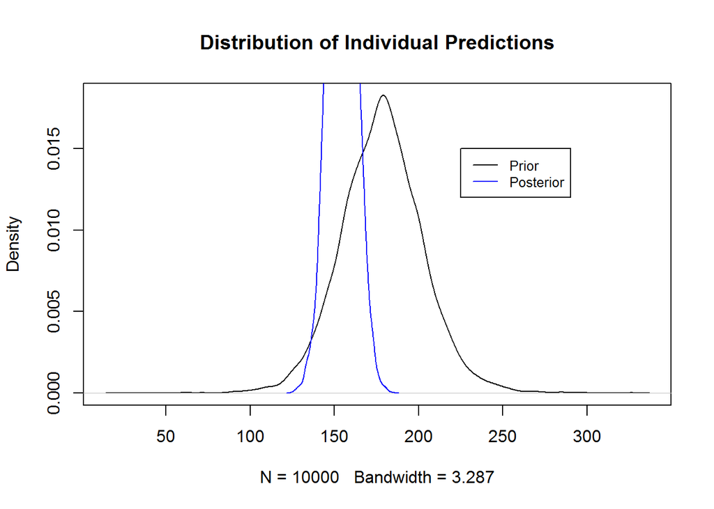

```r
plot(density(prior_indv), main = 'Distribution of Individual Predictions')
lines(density(posterior$y_pred), col = 'blue') #much narrower predicted interval
legend(225, .015, legend=c("Prior", "Posterior"), col=c("black", "blue"), lty=1:1, cex=0.8)
```

## 1.7 diagnostics

```r
check_treedepth(fit)
```

```
## 0 of 10000 iterations saturated the maximum tree depth of 10.
```

```r
check_energy(fit)
```

```
## E-BFMI indicated no pathological behavior.
```

```r
check_divergences(fit) #occurs if Markov chains did not completely explore the posterior
```

```
## 0 of 10000 iterations ended with a divergence.
```

# 2 Simple Linear Regression (One Predictor)

## 2.1 Data

The data is the height, weight, age and a categorical variable indicating whether the individual is male or female.

```r
data(Howell1)
d <- Howell1
d <- d[ d$age >= 18 , ]
str(d)
```

```
## 'data.frame':    352 obs. of  4 variables:
##  $ height: num  152 140 137 157 145 ...
##  $ weight: num  47.8 36.5 31.9 53 41.3 ...
##  $ age   : num  63 63 65 41 51 35 32 27 19 54 ...
##  $ male  : int  1 0 0 1 0 1 0 1 0 1 ...
```

It is best practice to keep the data outside of the environment.

```r
setwd("./2. linear regression")
xbar <- mean(d$weight)
N = length(d$weight)
height <- as.numeric(d$height)
weight <- as.numeric(d$weight)
stan_rdump(c("height", "N", "weight", "xbar"), file="linear_reg.data.R")
```

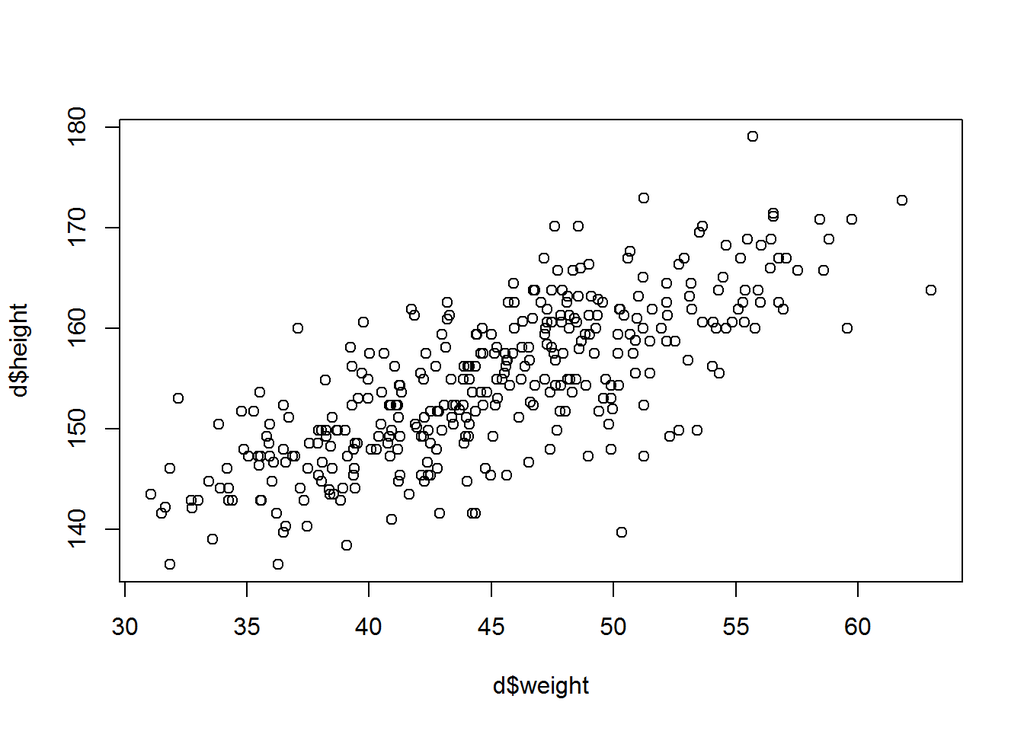

```r
plot(d$height ~ d$weight)
```

## 2.2 Prior Predictive Simulation

What are the reasonable prior assumptions on the beta coefficients?

For the slope, we can assume that weight and height are positively correlated. Therefore, we can use the log-normal distribution to restrict the effects to positive values.

A **prior predictive simulation** simulates *N* regression lines for the effect of weight on height.

```r
set.seed(2971)
N <- 100 # 100 lines
a <- rnorm( N , 178 , 20 ) #prior for alpha
b <- rlnorm( N , 0 , 1 ) #log normal prior for beta, to restrict effect of weight on height to be positive
```

We can visualize our prior predictive simulations using the code below.

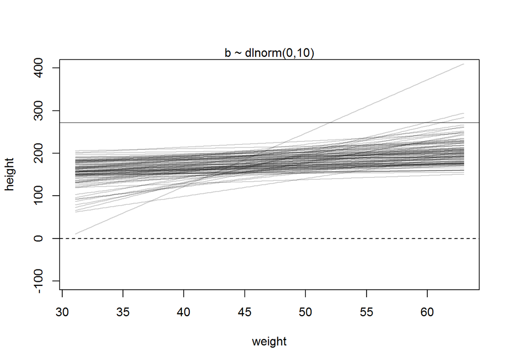

```r
#all the code below must be run as a chunk
plot(NULL, xlim=range(d$weight), ylim=c(-100,400), xlab="weight", ylab="height" )
abline(h=0, lty=2); abline(h=272, lty=1, lwd=0.5)
mtext("b ~ dlnorm(0,10)")
xbar <- mean(d$weight)
for (i in 1:N )
  curve(a[i] + b[i]*(x - xbar),
    from=min(d$weight), to=max(d$weight), add=TRUE, col=col.alpha("black",0.2))
```

## 2.3 Fitting the Model

The Stan script is written outside of the environment and is read in using the code below. Note that *weight* is centered.

```r
setwd("./2. linear regression")
writeLines(readLines("linear_regression.stan"))
```

```
## data{
##     int<lower=1> N;
##     real height[N];
##     real weight[N];
##  real xbar;
## }
## parameters{
##     real a;
##     real b;
##     real<lower=0> sigma;
## }
## model{
##     vector[N] mu;
##     sigma ~ exponential( .1 );
##     b ~ lognormal( 0 , 1 );
##     a ~ normal( 178 , 20 );
##
##     for ( i in 1:N ) {
##         mu[i] = a + b * (weight[i] - xbar);
##     }
##     height ~ normal( mu , sigma );
## }
## generated quantities{
##     vector[N] y_pred;
##     vector[N] mu;
##
##     for ( i in 1:N ) {
##         mu[i] = a + b * (weight[i] - xbar);
##     }
##
##     for (i in 1:N) {
##       y_pred[i] = normal_rng(mu[i], sigma);
##     }
## }
```

```r
setwd("./2. linear regression")
data <- read_rdump("linear_reg.data.R") #import data
```

```r
setwd("./2. linear regression")
fit <- stan(file='linear_regression.stan', data=data, seed=194838, chains = 1, warmup=1000, iter=10000)
```

We can get summry statistics for the posterior distributions.

```r
print(fit, c("a", "b", "sigma")) #overview
```

```
## Inference for Stan model: linear_regression.
## 1 chains, each with iter=10000; warmup=1000; thin=1;
## post-warmup draws per chain=9000, total post-warmup draws=9000.
##
##        mean se_mean   sd   2.5%    25%    50%    75%  97.5% n_eff Rhat
## a     154.6       0 0.27 154.07 154.42 154.60 154.79 155.13 11148    1
## b       0.9       0 0.04   0.82   0.87   0.90   0.93   0.98 10677    1
## sigma   5.1       0 0.19   4.74   4.97   5.09   5.23   5.50 11336    1
##
## Samples were drawn using NUTS(diag_e) at Thu Oct 31 14:04:25 2019.
## For each parameter, n_eff is a crude measure of effective sample size,
## and Rhat is the potential scale reduction factor on split chains (at
## convergence, Rhat=1).
```

## 2.4 Posterior Sampling

```r
posterior <- as.data.frame(fit)
```

Plot posterior against data

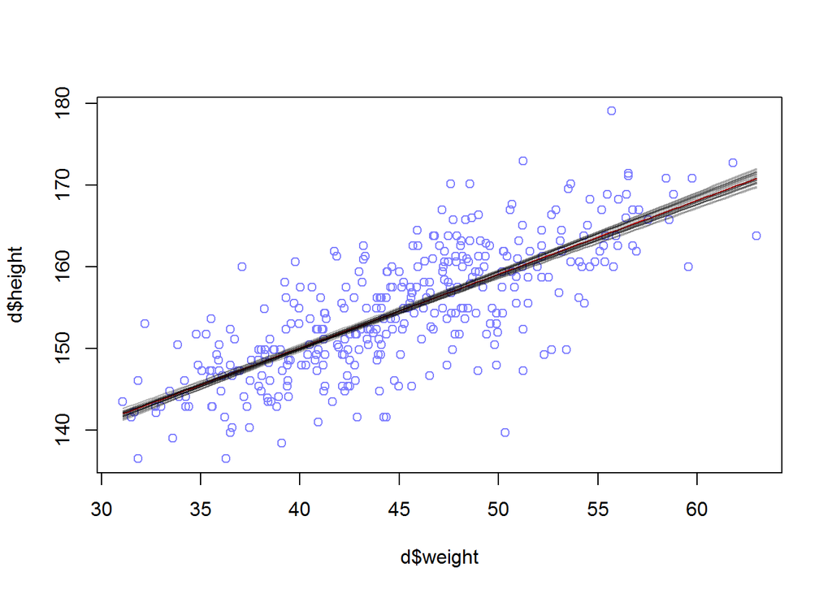

```r
plot(d$height ~ d$weight, col=rangi2)
curve(mean(posterior$a) + mean(posterior$b) * (x-xbar), add = TRUE, col = 'red') #x not specified... weird...
#add more lines
samples <- posterior[1:20,]
for ( i in 1:20 )
  curve( samples$a[i] + samples$b[i]*(x-xbar), col=col.alpha("black",0.3) , add=TRUE)
```

## 2.5 Plot prior samples and posterior

Plotting against the data.

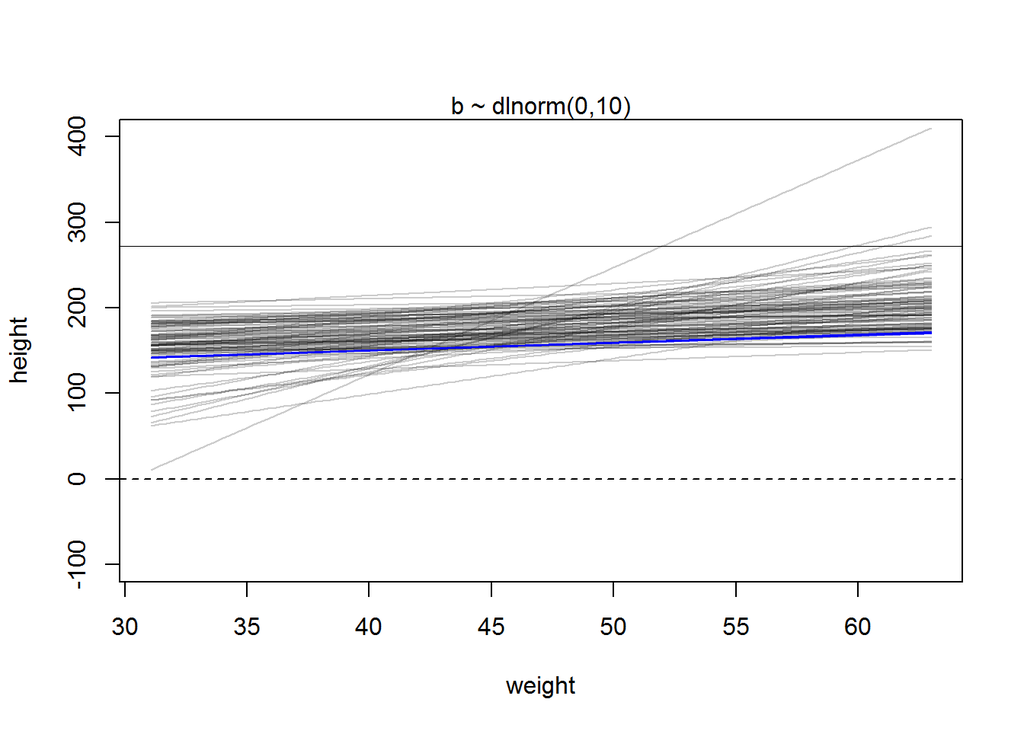

```r
plot(NULL, xlim=range(d$weight), ylim=c(-100,400), xlab="weight", ylab="height" )
abline(h=0, lty=2); abline(h=272, lty=1, lwd=0.5)
mtext("b ~ dlnorm(0,10)")
xbar <- mean(d$weight)
for (i in 1:N )
  curve(a[i] + b[i]*(x - xbar),
        from=min(d$weight), to=max(d$weight), add=TRUE, col=col.alpha("black",0.2)
  )
#posterior mean
curve(mean(posterior$a) + mean(posterior$b)*(x-xbar), col = 'red', add = TRUE)

#add more lines from the posterior distribution
samples <- posterior[1:20,]
for ( i in 1:20 )
  curve( samples$a[i] + samples$b[i]*(x-xbar), col=col.alpha("blue",0.3) , add=TRUE)
```

## 2.6 Regression interval

Regression interval- conditional on x

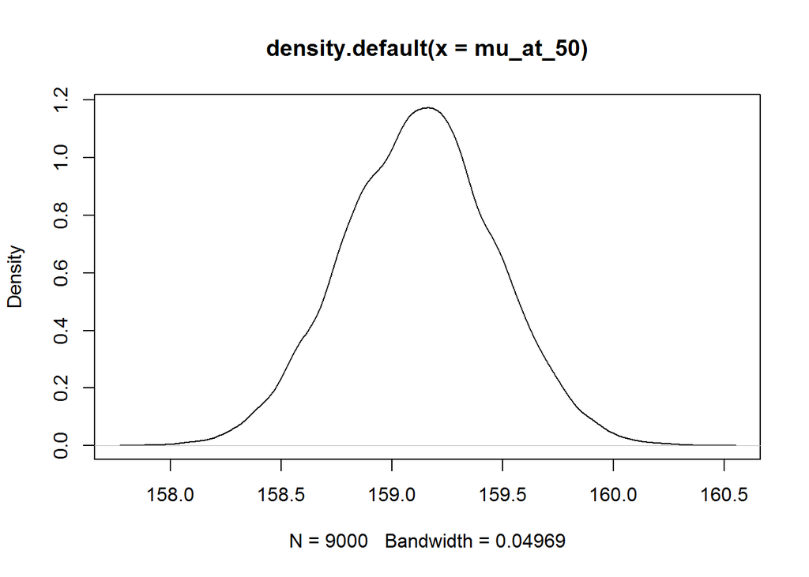

```r
mu_at_50 <- posterior$a + posterior$b*(50-xbar) #if x = 50
plot(density(mu_at_50))
```

```r
HPDI(mu_at_50) #still works outside of "rethinking" object!
```

```
##    |0.89    0.89|
## 158.5765 159.6688
```

Regression interval- (across all x).

You can use the link function to do this, or just create a matrix object below.

```r
#create object
weight.seq <- seq( from=25 , to=70 , by=1 )
obj <- matrix(0, nrow=nrow(samples), ncol=length(weight.seq))
for (i in 1:20)
  for (j in 1:46)
    obj[i,j] <- (samples$a[i] + samples$b[i]*(weight.seq[j]-xbar))
```

Summarize the distribution of mu at each value of x.

```r
mu.mean <- apply( obj , 2 , mean )
mu.HPDI <- apply( obj , 2 , HPDI , prob=0.89 )
```

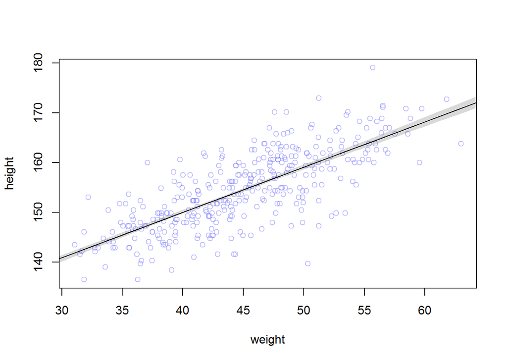

```r
plot( height ~ weight , data=d , col=col.alpha(rangi2,0.5) ) # plot raw data
lines( weight.seq , mu.mean ) # plot the posterior regression line
shade( mu.HPDI , weight.seq ) # plot a shaded region for 89% HPDI
```

## 2.7 Prediction intervals

Simulating observations.

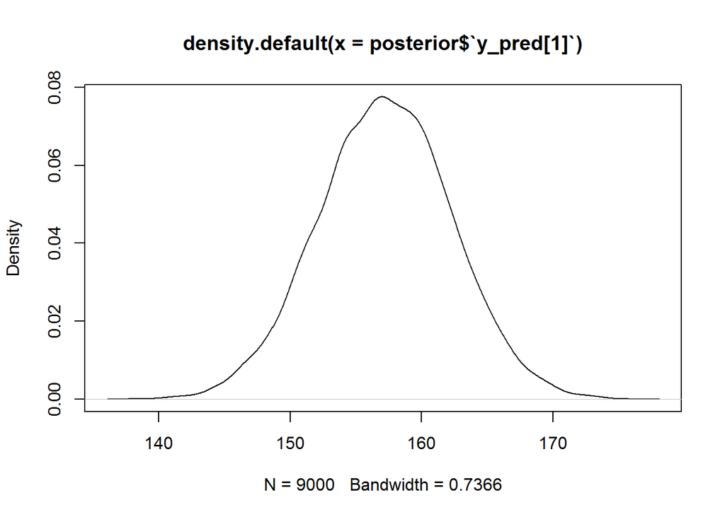

```r
plot(density(posterior$`y_pred[1]`))
```

```r
#or you can generate in R
weight.seq <- 25:70
mu.link <- function(weight) posterior$a + posterior$b*( weight - xbar )
sim.height <- sapply( weight.seq , function(weight)
  rnorm(
    n=nrow(posterior) ,
    mean=posterior$a + posterior$b*( weight - xbar ) ,
    sd=posterior$sigma ) )
height.PI <- apply( sim.height , 2 , PI , prob=0.89 ) #uses fn from rethinking... you can also use quartile...
```

Plotting

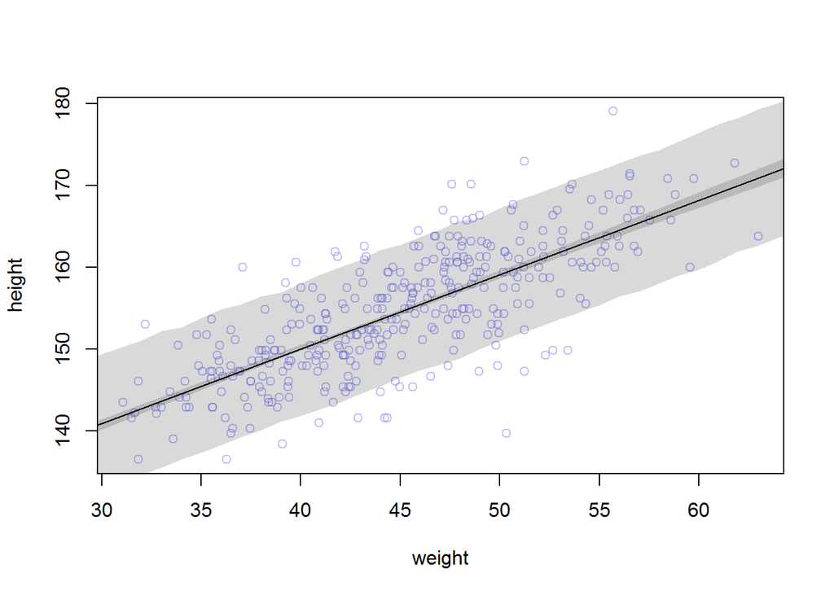

```r
plot( height ~ weight , d, col=col.alpha(rangi2,0.5) ) #regression line
lines( weight.seq , mu.mean ) # draw HPDI region for line
shade( mu.HPDI , weight.seq ) # draw PI region for simulated heights
shade( height.PI , weight.seq )
```